# Study Population Summary

July 09, 2025

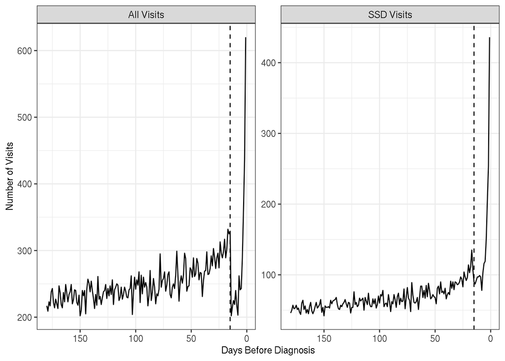

In the 180-days prior to the index diagnosis, 5901 patients of the total 6643 patients had at least one healthcare visit prior to the index for any reason. Break down of visits that occurred prior to index:

```
## # A tibble: 1 x 4
##   outpatient inpatient    ed other
##        <int>     <int> <int> <int>
## 1      40433      1797  4735  9191
```

There were 742 patients whose first visit occurred on the index date. Of these patients whose first visit occurred on the index date, 742 had temperature reading on the index visit as well, with 112 (15.09%) patients having a fever based on a temp >= 100F.

Break down of visits that occurred on index for individuals whose first visit occurred on the index date:

```
## # A tibble: 4 x 3
##   Setting        n percent
##   <chr>      <int> <chr>
## 1 outpatient   322 19.78
## 2 inpatient    323 19.84
## 3 ed           724 44.47
## 4 other        259 15.91
```

Break down of visits that occurred on index for individuals whose first visit occurred on the index date and had a fever based on a temp >= 100F:

```
## # A tibble: 4 x 3
##   Setting        n percent
##   <chr>      <int> <chr>
## 1 outpatient    98 33.45
## 2 inpatient     54 18.43
## 3 ed           105 35.84
## 4 other         36 12.29
```

Break down of visits that occurred on index for individuals who had visits prior to index:

```
## # A tibble: 4 x 3
##   Setting        n percent
##   <chr>      <int> <chr>
## 1 outpatient  2350 18.26
## 2 inpatient   2740 21.29
## 3 ed          5612 43.60
## 4 other       2169 16.85
```

There were 5702 patients that had a healthcare visit prior to the change-point of 14 days. However, there were only 2239 patients that had a healthcare visit during the delay window (i.e.,[-14, 0)). There were a total of 3971 visit days during the delay window among the 2239 patients, of which 96.63% of the visit days had a temperature reading. Among visit days with a temperature, 5.94% had a fever reading of >=100F.

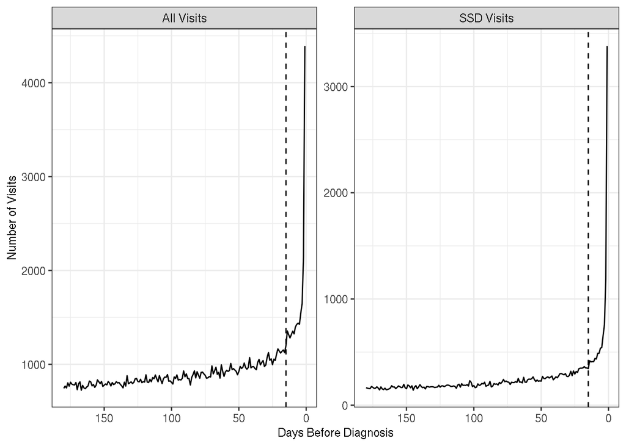

*Curves by cutoff*

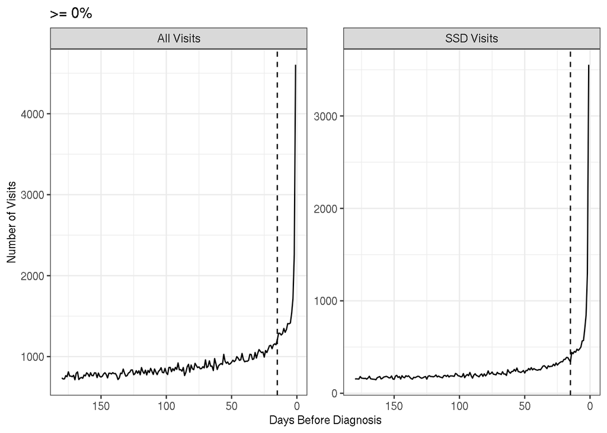

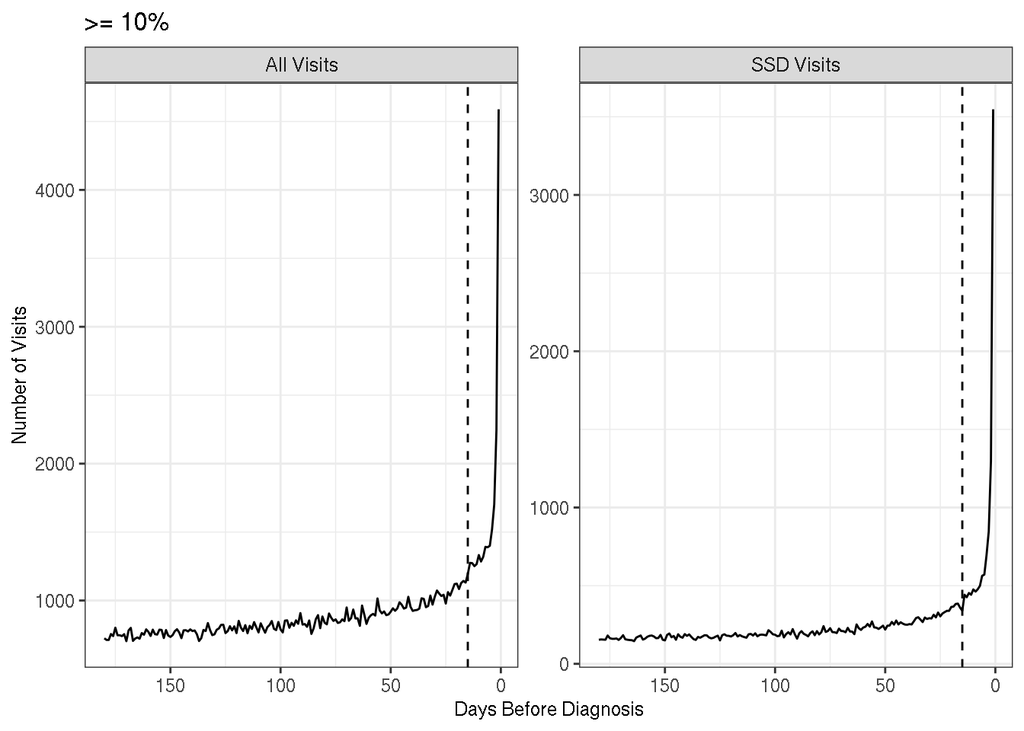

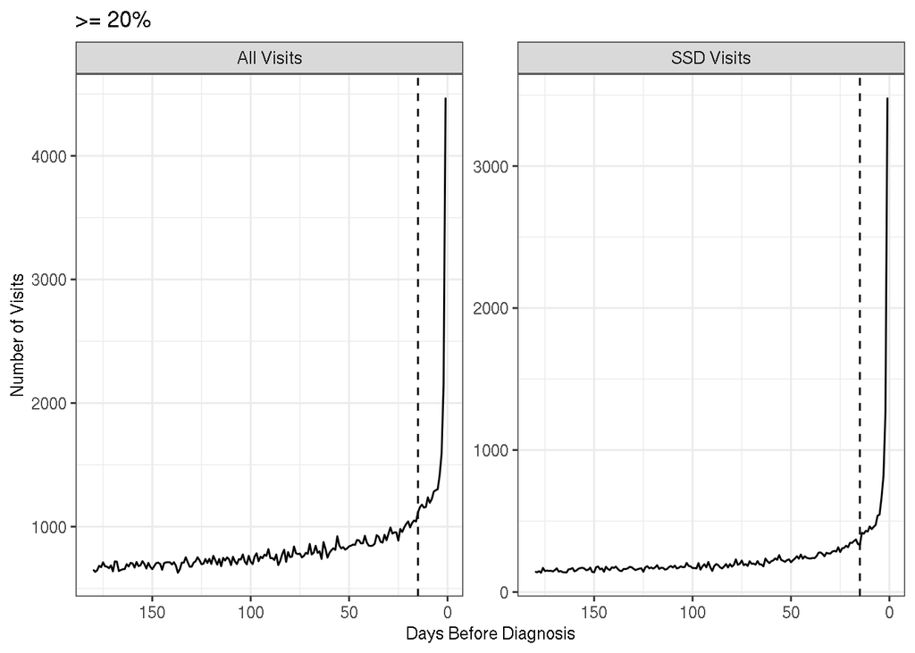

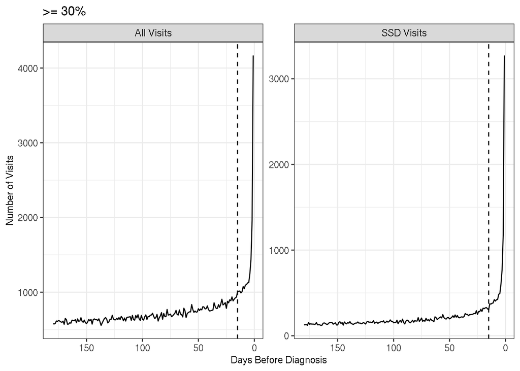

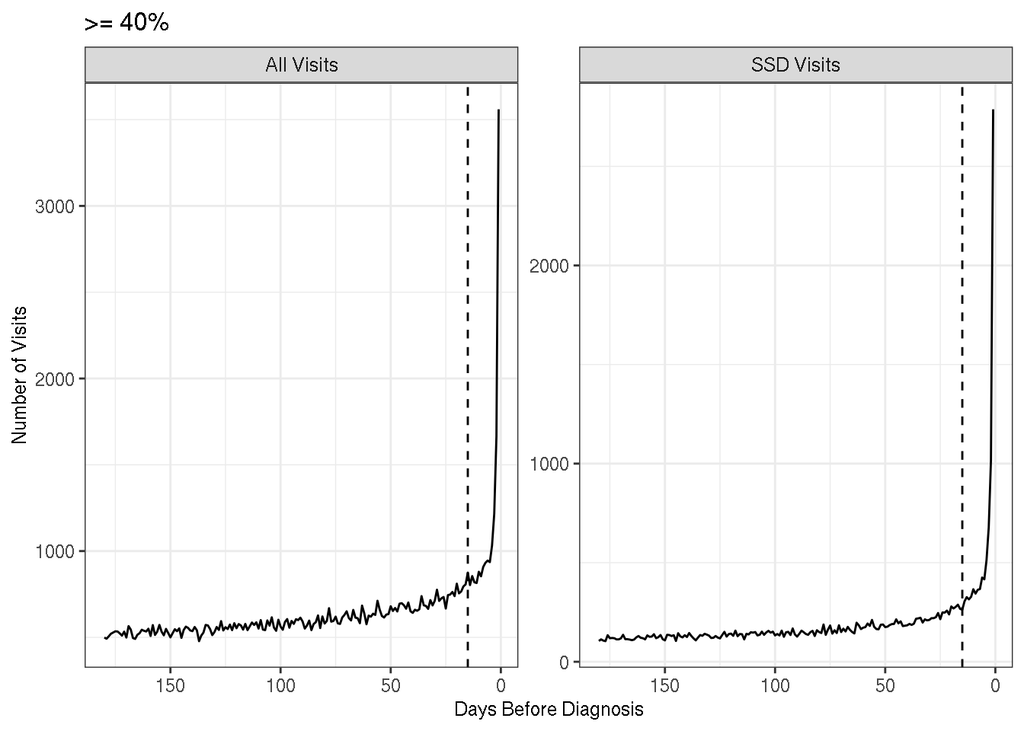

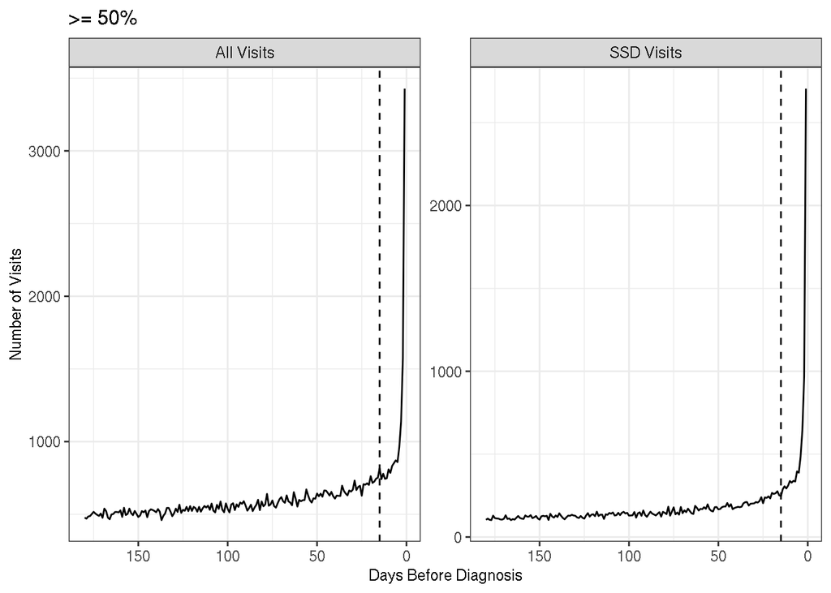

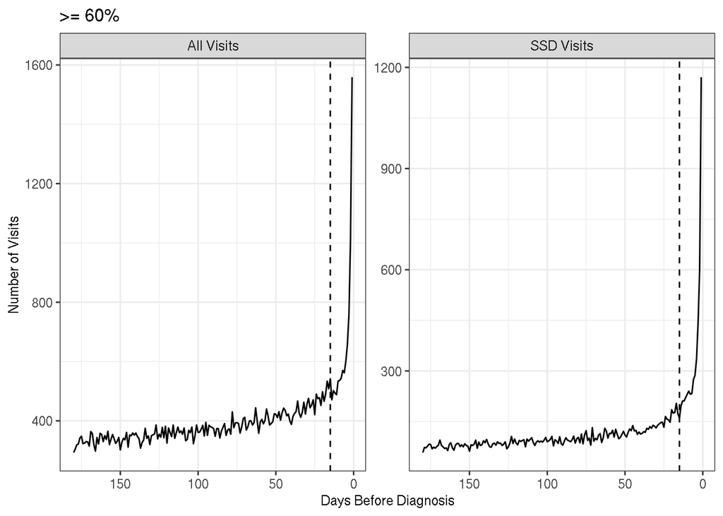

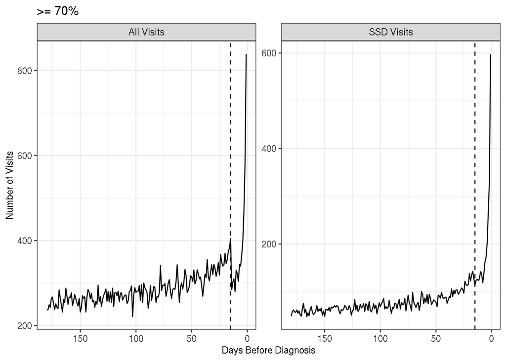

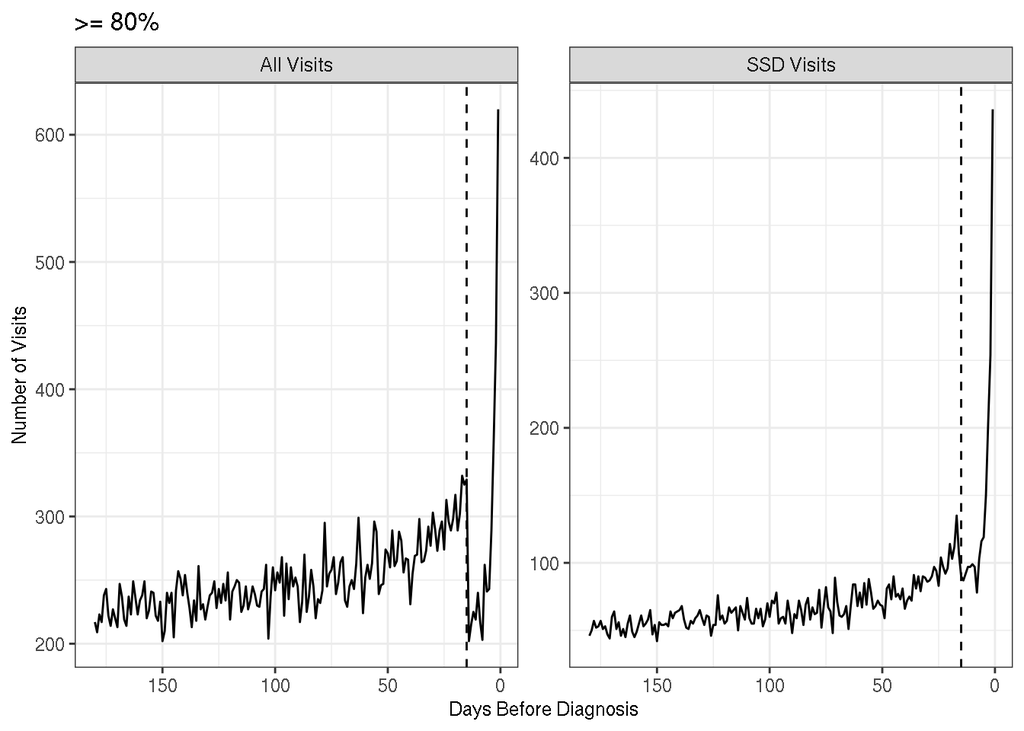

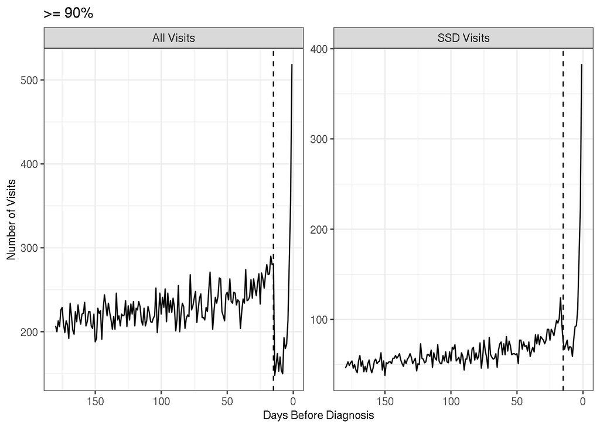

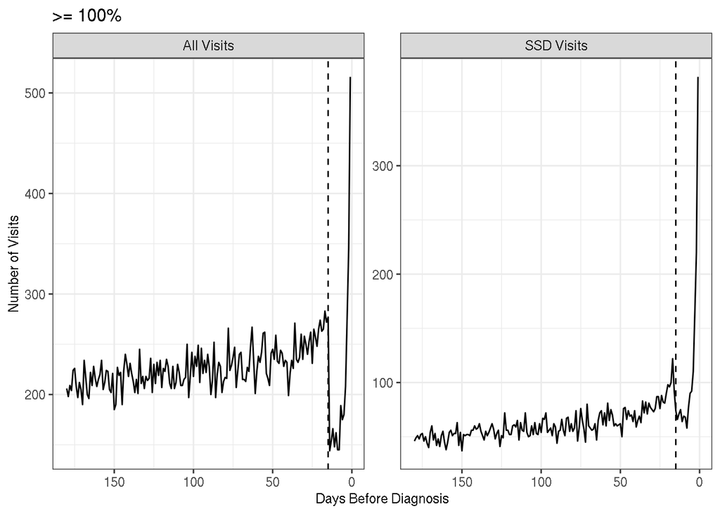